# Homework 1

Kevork Sulahian

## Read the dataset movies3.csv into R

```r
movies = read.csv("movies3.csv")
```

## The variable gross_adjusted is showing gross box office of the movie adjusted by inflation. The variable budget_adjusted shows the budget of the movie adjusted by inflation

Write a code that will make variables gross_adjusted and budget_adjusted in 1000 USD. Dont create new variable, just overwrite the old ones. (1 point)

```r
gross <- paste0(movies$gross_adjusted, " USD")
budget <-paste0(movies$budget_adjusted, " USD")
```

What is the minimum for box office ? What is the minimum for budget ? (1 point)

```r
movies[movies$gross ==min(movies$gross),]
```

```
##              title genre_first year duration gross_adjusted
## 563 The Jimmy Show      Comedy 2001       96            973
##     budget_adjusted gross  budget cast_facebook_likes reviews    index
## 563         2076115   703 1500000                 920      30 1.384077
##     Rated         Genre     Director
## 563     R Comedy, Drama Frank Whaley
##                                         Writer
## 563 Jonathan Marc Sherman (play), Frank Whaley
##                                                  Actors
## 563 Frank Whaley, Carla Gugino, Ethan Hawke, Lynn Cohen
##                                                                                                                             Plot
## 563 A failed New Jersey inventor embarks on a career as a standup comic, turns to drink, and labors to keep his family together.
##     Language Country Awards Metascore imdbRating imdbVotes Production
## 563  English     USA 1 win.        39        5.3       495 First Look
##           DVD   Release Release_Month Release_Day Release_year OscarWon
## 563 5/27/2003 1/16/2002             1          16         2002        0
##     OtherWin OscarNom OtherNom
## 563        1        0        0
```

```r
movies[movies$budget == min(movies$budget),]
```

```
##         title genre_first year duration gross_adjusted budget_adjusted
## 869 Tarnation   Biography 2003       88         788666             290
##      gross budget cast_facebook_likes reviews    index   Rated
## 869 592014    218                  78     186 1.332174 UNRATED
##                      Genre          Director            Writer
## 869 Documentary, Biography Jonathan Caouette Jonathan Caouette
##                                                             Actors
## 869 Renee Leblanc, Jonathan Caouette, Adolph Davis, Rosemary Davis
##                                                                                                                                                                                                                                      Plot
## 869 Filmmaker Jonathan Caouette's documentary on growing up with his schizophrenic mother -- a mixture of snapshots, Super-8, answering machine messages, video diaries, early short films, and more -- culled from 19 years of his life.
##     Language Country                   Awards Metascore imdbRating
## 869  English     USA 9 wins & 12 nominations.        87        7.2
##     imdbVotes Production  DVD Release Release_Month Release_Day
## 869     5,906 Wellspring <NA>    <NA>            NA          NA
##     Release_year OscarWon OtherWin OscarNom OtherNom
## 869           NA        0        9        0       12
```

The variable genre_first is showing which genre was mentioned first on the movies imdb webpage

How many Action movies are there? How many comedies ? (2 point)

```r
tb <- table(movies$genre_first)

# 721 Action
# 844 Comedy
```

Create a new dataframe with the most popular geners. Take those movies only, whose genre appear in the dataframe more than 100 times.(3 points)

Hint Suppose you want to subset the mtcars dataset in a way that will have only cars who has 6 or 8 cylinder. One way to go with it is the following: df <- mtcars[mtcars$cyl == 6 | mtcars$cyl ==8,]

However the most efficient way will be: df <- mtcars[mtcars$cyl %in% c(6,8),]

```r
library(dplyr)
tb_names <- names(tb[tb >100])
top_movies <- filter(movies, genre_first %in% tb_names)
head(top_movies)
```

```
##         title genre_first year duration gross_adjusted budget_adjusted
## 1        Zoom      Action 2006       83       14142117        42555556
## 2 Zoolander 2      Comedy 2016      102       29451448        51065177
## 3   Zookeeper      Comedy 2011      102       87570655        87177413
## 4  Zombieland   Adventure 2009       88       86365946        26964263
## 5      Zodiac       Crime 2007      162       39077724        76858659
## 6 Zero Effect      Comedy 1998      116        2978040         7519018
##      gross   budget cast_facebook_likes reviews    index Rated
## 1 11631245 35000000                5022     176 1.215873    PG
## 2 28837115 50000000               24107     376 1.021304 PG-13
## 3 80360866 80000000                5392     305 1.089718    PG
## 4 75590286 23600000               28011     998 1.142553     R
## 5 33048353 65000000               36928     966 1.182441     R
## 6  1980338  5000000                1209     232 1.503804     R
##                       Genre        Director
```

[output cut: 55 more lines]

what is the standard deviation of the imdbRating.(2 points) Hint. If you are getting NA after running the function, one reason can be that the variable has NA inside. Look at the help of the function, specifically for the argument na.rm

```r
sd(movies$imdbRating, na.rm = TRUE)
```

```
## [1] 1.042546
```

On average, which gener has made the highest box office revenue ? (5 points)

Hint: use function ?aggregate (https://goo.gl/DUyftz) or anything else, but dont give me lenghty code

```r
a <-aggregate(top_movies, by = list(top_movies$genre_first), FUN = 'mean', drop = TRUE, simplify = TRUE)
a <- a[c("Group.1","gross_adjusted")]
a
```

```
##     Group.1 gross_adjusted
## 1    Action      116323930
## 2 Adventure      126427147
## 3 Biography       72316466
## 4    Comedy       61421028
## 5     Crime       58571121
## 6     Drama       64764868
## 7    Horror       59965089
```

Using ggplot construct scatterplot between imdbRating and Metascore. (3 points)

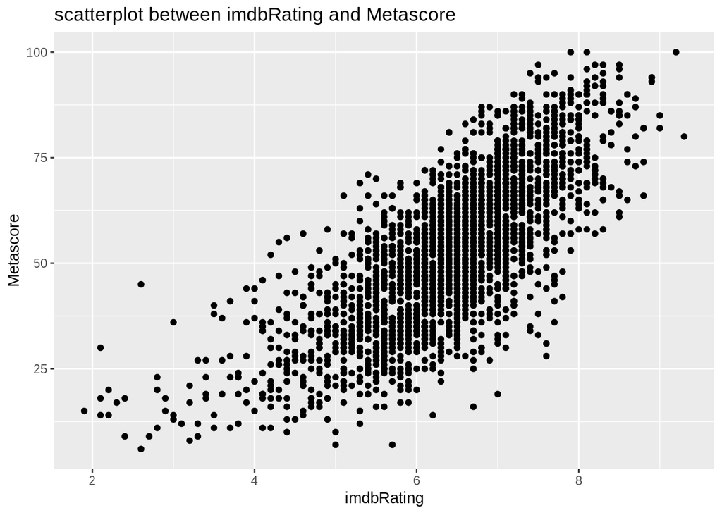

```r
library(ggplot2)
attach(top_movies)
ggplot(top_movies, aes(x = imdbRating, y = Metascore)) + geom_point() + ggtitle("scatterplot between imdbRating and Metascore")
```

Do the same thing for each genre (using facet_grid() or facet_wrap()) (3 points)

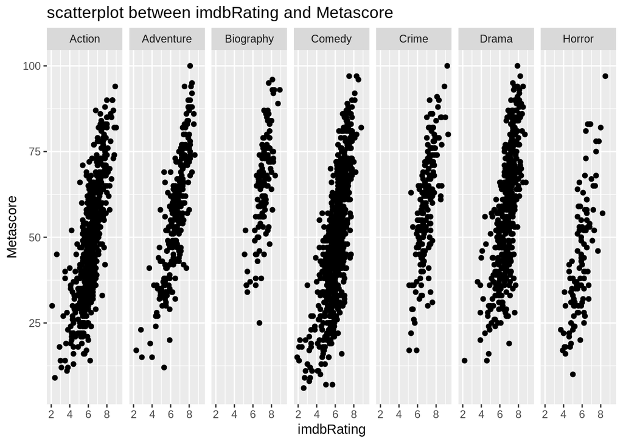

```r
ggplot(top_movies, aes(x = imdbRating, y = Metascore)) + geom_point() + ggtitle("scatterplot between imdbRating and Metascore") + facet_grid(.~genre_first)
```

Construct histogram for imdbRating for each genre (3 point)

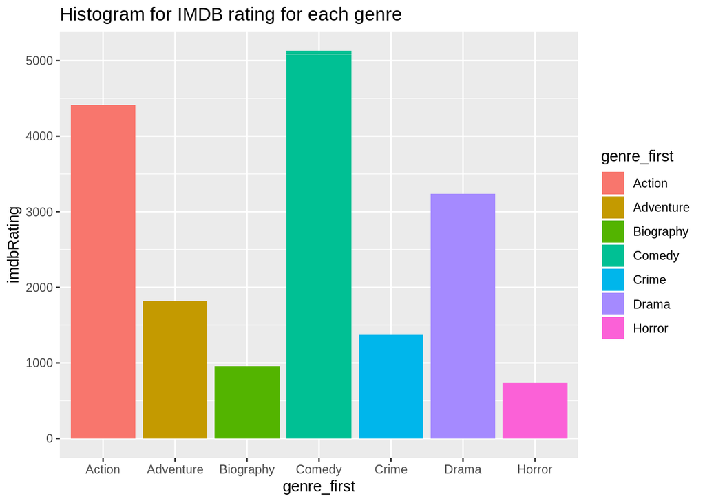

```r
ggplot(top_movies, aes(x = genre_first, y = imdbRating, fill = genre_first)) + geom_histogram(stat = "identity") +
  ggtitle("Histogram for IMDB rating for each genre")
```

Calculate mean, median and standard deviation of imdbRating and Metascore for each genre.(4 points)

```r
mean(imdbRating, na.rm = T)
```

```
## [1] 6.382725
```

```r
median(imdbRating, na.rm = T)
```

```
## [1] 6.5
```

```r
sd(imdbRating, na.rm = T)
```

```
## [1] 1.035619
```

```r
mean(Metascore, na.rm = T)
```

```
## [1] 52.90433
```

```r
median(Metascore, na.rm = T)
```

```
## [1] 52
```

```r
sd(Metascore, na.rm = T)
```

```
## [1] 17.87848
```

Create a binary variable based on the column OscarWon taking the valu 1, if the film got an Oscar and 0 if it does not. You can use ifelse for this.(3 points)

```r
top_movies$binary_var = ifelse(OscarWon > 0, 1, 0)
```

Write a code to see what genre films have the highest probability of being awarded Oscar(2 points)

```r
a <- top_movies %>% group_by(genre_first) %>% summarise(won = sum(binary_var))
a[order(-a$won),]
```

```
## # A tibble: 7 x 2
##   genre_first   won
##   <fct>       <dbl>
## 1 Drama          60
## 2 Adventure      36
## 3 Biography      35
## 4 Action         32
## 5 Comedy         28
## 6 Crime          22
## 7 Horror          1
```

use visualization to illustrate the difference in means of budgets of films winning Oscar with those not winning one.(3 points)

[figure not shown]

```r
a <- top_movies %>% group_by(binary_var) %>% summarise(means = mean(gross_adjusted))
ggplot(a, aes(x = a$binary_var,y = a$means, fill = a$binary_var)) + geom_histogram(stat= "identity") +
  labs(x = "No Oscar vs at least 1 Oscar", y = "Budget", title = "Budget on oscar winning movies")
```